# SP_29__GL

## Групове заняття 15

### Тема 2: Обробка масивів даних. Машинне навчання з учителем

### Заняття 29: Лінійна регресія

### Результати заняття

*(слухач зможе)*

1. Вміти пояснити поняття `Лінійна регресія`.
2. Використати на практиці `метод найменших квадратів` для знаходження коефіцієнтів для лінійної регресії.

**НАВЧАЛЬНИЙ ЧАС**: 2 години.

**Навчальна література:**

1. The Python Tutorial [Електронний ресурс] – Режим доступу до ресурсу: https://docs.python.org/3/tutorial/index.html.
2. Pandas. Working with text data [Електронний ресурс] – Режим доступу до ресурсу: https://pandas.pydata.org/docs/user_guide/text.html
3. Що таке лінійна регресія: повний гайд від robot_dreams [Електронний ресурс] – Режим доступу до ресурсу: https://robotdreams.cc/uk/blog/437-shcho-take-liniyna-regresiya

### ПЛАН ЗАНЯТТЯ

| № з/п | Навчальні питання | Час, хв |
| --- | --- | --- |
| 1 | **ВСТУПНА ЧАСТИНА** | 5 |
| 2 | **ОСНОВНА ЧАСТИНА** | 80 |
| 2.1 | Лінійна регресія. Основні засади та поняття | 40 |
| 2.2 | Лінійна регресія. Функція вартості | 40 |
| 3 | **ЗАКЛЮЧНА ЧАСТИНА** | 5 |

### Навчальне питання 1. Лінійна регресія. Основні засади та поняття

*Теорія - 20 хв, практика - 20 хв*

Ще на початку 18 століття вчені почали розвивати питання лінійної регресії. Метою було покращення навігації та прогнозування зміни положення небесних світил. По своїй суті це алгоритм пошуку лінійної залежності між кількома змінними. Окрім того, було встановлено, що усереднення кількох вимірів однієї величини дають кращий результат.

Ідея алгоритму полягає у тому щоб описати виміри величини прямою лінією на площині.

Для прикладу є 3 точки, якщо ми можемо провести через них пряму лінію - значить між ними є лінійна залежність.

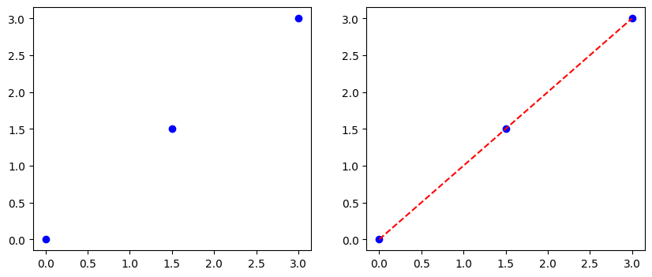

```python
# Лінійна регресія
import matplotlib.pyplot as plt
import numpy as np

a1 = np.linspace(0,3, 3)
b1 = np.linspace(0,3,3)

a2 = np.linspace(0,3, 300)
b2 = np.linspace(0,3,300)

fig, ax = plt.subplots(nrows=1, ncols=2, figsize=(10,4), dpi=100)

ax[0].plot(a1, b1,  'bo', label='Points');
ax[1].plot(a1, b1,  'bo', label='Line');
ax[1].plot(a2, b2, 'r--');
```

У реальному житті, як правило, виміри певної величини являють собою набір чисел наближених до реальних значень. Тому знаходження лінійної залежності - є вибір найкращого варіанту. На графіку нижче наведено варіант знаходження наближення червона та жовта лінії.

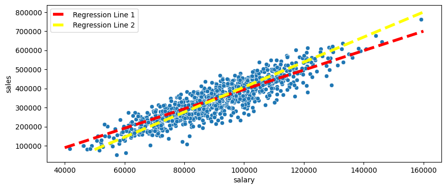

```python
# Варіанти знаходження лінійної регресії
import seaborn as sns
import matplotlib.pyplot as plt

import pandas as pd
import numpy as np

df = pd.read_csv('dm_office_sales.csv')
plt.figure(figsize=(10, 4), dpi=100)
sns.scatterplot(x="salary", y="sales", data=df);
sns.lineplot(x=[40000, 160000], y=[90000, 700000], color='red', linestyle='--', linewidth=4, label='Regression Line 1');
sns.lineplot(x=[50000, 160000], y=[80000, 800000], color='yellow', linestyle='--', linewidth=4, label='Regression Line 2');
```

Для вирішення такого завдання логічним припущенням є пошук варіанту із найменшими відхиленнями. Англійською мовою відхилення будуть вимовлятися як **residual errors**. Одним із таких методів є метод **найменших квадратів**.

#### Метод найменших квадратів

Суть методу полягає у мінімізації суми квадратів різниці між розрахованим значенням лінійної регресії та виміряним значенням. Вибір квадратів пов'язано із зручністю підрахунку для від'ємних та додатних відхиленнях. Рівняння прямої має наступний вигляд:

$$ \hat{y} = \beta_1 x + \beta_0 $$

- $ \beta_1 $ - відповідає за нахил лінії,
- $ \beta_0 $ - перетин лінії з віссю ординат (*bias - упередження*).

Щоб обчислити значення коефіцієнтів $\beta_0$ та $\beta_1$ застосуємо **метод найменших квадратів**

$$ \hat{y}=\beta_1 x + \beta_0 $$

$$ \beta_1 = \frac{\displaystyle\sum_{i=0}^n (x_i-\tilde{x})(y_i-\tilde{y})}{\displaystyle\sum_{i=0}^n (x_i-\tilde{x})^2}$$

$$ \beta_0 = \hat{y}-\beta_1 \tilde{x} $$

Розглянемо наступну вибірку:

```python
import matplotlib.pyplot as plt
from random import randint

feature_value = [randint(0, 10) + _*5 + 20 for _ in range(10)]
target_value = [randint(10, 30) + _*5 + 20 for _ in range(10)]
```

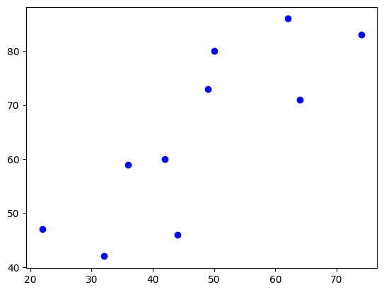

```python
plt.plot(feature_value, target_value, 'bo', label='Points 1');
```

Для застосування вищезазначених виразів послідовність дій наступна:

1. Знаходження середніх значень для змінних $\tilde{x}$ та $ \tilde{y}$.
2. Знаходження різниць між значеннями виміряними та середніми значеннями:

   $(x - \tilde{x})$ та $(y - \tilde{y})$
3. Розрахунок квадрату відхилень $(x - \tilde{x})^2$
4. Знаходження коефіцієнтів $\beta_0$ та $\beta_1$.

```python
import pandas as pd
import seaborn as sns

# Генерація даних
xx = np.random.uniform(0, 10, 100)
yy = 2 * xx + np.random.normal(0, 1, 100)

# Формування датафрейму
df = pd.DataFrame({'X': xx, 'y': yy})
# Виконання пунктів 1 та 2
df['dx'] = df['X'].mean() - df['X']
df['dy'] = df['y'].mean() - df['y']
# Виконання пункту 3
df['dx2'] = df['dx']**2

df['dxdy'] = df['dx'] * df['dy']
df
```

|  | X | y | dx | dy | dx2 | dxdy |
| --- | --- | --- | --- | --- | --- | --- |
| 0 | 2.833567 | 5.222789 | 1.658163 | 3.914509 | 2.749506 | 6.490895 |
| 1 | 5.096580 | 11.174272 | -0.604850 | -2.036974 | 0.365843 | 1.232063 |
| 2 | 9.269547 | 20.129306 | -4.777816 | -10.992008 | 22.827530 | 52.517796 |
| 3 | 3.799802 | 7.415198 | 0.691929 | 1.722099 | 0.478766 | 1.191570 |
| 4 | 0.382693 | 1.981147 | 4.109037 | 7.156151 | 16.884189 | 29.404891 |
| ... | ... | ... | ... | ... | ... | ... |
| 95 | 2.872256 | 6.259968 | 1.619475 | 2.877330 | 2.622698 | 4.659763 |
| 96 | 8.562425 | 16.594339 | -4.070694 | -7.457041 | 16.570553 | 30.355337 |
| 97 | 2.361857 | 4.257774 | 2.129873 | 4.879524 | 4.536361 | 10.392768 |
| 98 | 5.878696 | 11.424319 | -1.386965 | -2.287021 | 1.923672 | 3.172019 |
| 99 | 2.059426 | 4.862775 | 2.432304 | 4.274523 | 5.916104 | 10.396940 |

100 rows × 6 columns

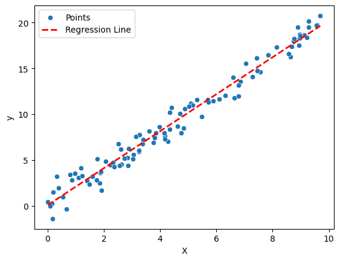

```python
# Виконання пункту 4
b1 = df['dxdy'].sum() / df['dx2'].sum()
b0 = df['y'].mean() - b1 * df['X'].mean()

# Побудова графіків
sns.scatterplot(x='X', y='y', data=df, label='Points');
sns.lineplot(x=xx, y=[b1*x + b0 for x in xx], color='red',
 linestyle='--', linewidth=2, label='Regression Line');
```

Таким чином, знайдені коефіцієнти дозволяють знаходити значення цільової змінної по відомому значенню ознак.

```python
print("="*40)
print(f"Коефіцієнт b0:\t{b0:.4f}")
print(f"Коефіцієнт b1:\t{b1:.4f}")
print("="*40)
```

```
========================================
Коефіцієнт b0:	0.0677
Коефіцієнт b1:	2.0192
========================================
```

```python
# Так для значення х=70, цільова функція прийме значення:
print(f'Цільова функція для x=70: {b1*70 + b0}')
```

```
Цільова функція для x=70: 141.41010503965293
```

Для знаходження таких коєфіцієнтів вже існує відповідний метод у бібліотеці `Scikit-learn`

```python
from sklearn.linear_model import LinearRegression

md = LinearRegression()
md.fit(df[['X']], df['y'])
```

```
LinearRegression()
```

[output not shown]

```python
predicted = md.predict([[70]]);
print(predicted[0]);
```

```
141.41010503965296
```

> **Практичне завдання 1**

> Провести розрахунки та обчислити коефіцієнти для прогнозування значень для наступного масиву даних.
> 1. X = [16, 23, 27, 25, 32, 38, 41, 36, 49, 42]
> 2. y = [73, 78, 97, 93, 121, 127, 135, 135, 156, 155]

```python
# Згенеровані дані для практичного завдання 1
import random

random.seed(49)
X1 = [random.randint(0, 10) + _*3 + 15 for _ in range(10)]
Y1 = [random.randint(40, 60) + _*9 + 25 for _ in range(10)]
```

### Навчальне питання 2. Лінійна регресія. Функція вартості

*Теорія - 20 хв, практика - 20 хв*

Розглянутий вище приклад дозволяє знайти вираз для знаходження значень цільової змінної, що має лінійну залежність від однієї вхідної величини (ознаки). При залежності значень цільової змінної від декількох ознак застосовується інший підхід, який базується на `функції вартості`. При цьому лінійні функції будуються для кожної ознаки. Загальний вираз для функції вартості має наступний вигляд

$$ J(\beta) = \displaystyle\sum_{i=0}^n \beta_i x_i $$

Оскільки, ми маємо знайти залежність, яка дає найменші похибки для усіх ознак, то по суті ми знаходимо мінімуми для кожної із лінійних функцій. Ці мінімуми зручно трансформувати у квадратах різниці між значеннями відхилень цільової змінної. Запис такої ідеї здійснюється наступним чином

$$ J(\beta) = \frac{1}{2m}\displaystyle\sum_{j=0}^m (y^j-\tilde{y}^j)^2 $$

`m` - кількість ознак; `2` - для зручності подальших розрахунків

Значення $ \tilde{y} $ для кожної ознаки визначається на основі полінома

$$ \tilde{y}=\displaystyle\sum_{i=0}^n \beta_i x_i $$

Виходячи із цього загальний вираз матиме вигляд:

$$ J(\beta) = \frac{1}{2m}\displaystyle\sum_{j=0}^m (y^j-\displaystyle\sum_{i=0}^n \beta_i x_i^j)^2 $$

Взявши похідну вираз для мінімізації функції матиме вигляд

$$ J(\beta) = \frac{1}{m}\displaystyle\sum_{j=0}^m (y^j-\displaystyle\sum_{i=0}^n \beta_i x_i^j)(-x_k^j) $$

Таке рівняння не має аналітичного рішення. У такому випадку застосовують числові методи, наприклад градієнтний метод спуску.

Для прикладу розглянемо набір даних, який характеризує залежність між витратами на підготовку матеріалів для розповсюдження через телебачення, радіо, соціальні мережі та ефект, що отримується.

```python
import pandas as pd
import numpy as np
import matplotlib.pyplot as plt
import seaborn as sns

# Формування датафрейму
df = pd.read_csv('influence.csv')
df.head()
```

|  | TV | radio | social | effectiveness |
| --- | --- | --- | --- | --- |
| 0 | 230.1 | 37.8 | 69.2 | 22.1 |
| 1 | 44.5 | 39.3 | 45.1 | 10.4 |
| 2 | 17.2 | 45.9 | 69.3 | 9.3 |
| 3 | 151.5 | 41.3 | 58.5 | 18.5 |
| 4 | 180.8 | 10.8 | 58.4 | 12.9 |

```python
# Загальні витрати на розробку
df['total_cost'] = df['TV'] + df['radio'] + df['social']
df.head()
```

|  | TV | radio | social | effectiveness | total_cost |
| --- | --- | --- | --- | --- | --- |
| 0 | 230.1 | 37.8 | 69.2 | 22.1 | 337.1 |
| 1 | 44.5 | 39.3 | 45.1 | 10.4 | 128.9 |
| 2 | 17.2 | 45.9 | 69.3 | 9.3 | 132.4 |
| 3 | 151.5 | 41.3 | 58.5 | 18.5 | 251.3 |
| 4 | 180.8 | 10.8 | 58.4 | 12.9 | 250.0 |

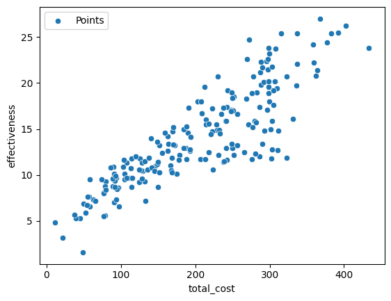

```python
sns.scatterplot(x='total_cost', y='effectiveness', data=df, label='Points');
```

Для побудови лінійної регресії використаємо метод найменших квадратів, який реалізований у бібліотеці `seaborn`.

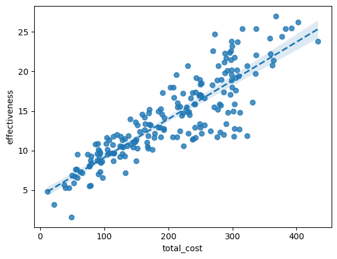

```python
sns.regplot(x='total_cost', y='effectiveness', data=df,
label='Regression Line',  line_kws={'linestyle':'--', 'linewidth':2});
```

У отриманому графіку вже побудована лінія регресії. Щоб отримати значення коефіцієнтів можна використати бібліотеку `numpy`.

```python
import numpy as np

[b1, b0] = np.polyfit(df['total_cost'], df['effectiveness'], 1)

print(f'Коефіцієнт b1: {b1}')
print(f'Коефіцієнт b0: {b0}')
```

[output not shown]

`1` - аргумент, який показує, що застосовується **степінь полінома 1**

Тепер побудуємо лінійну регресію на основі отриманих коефіцієнтів:

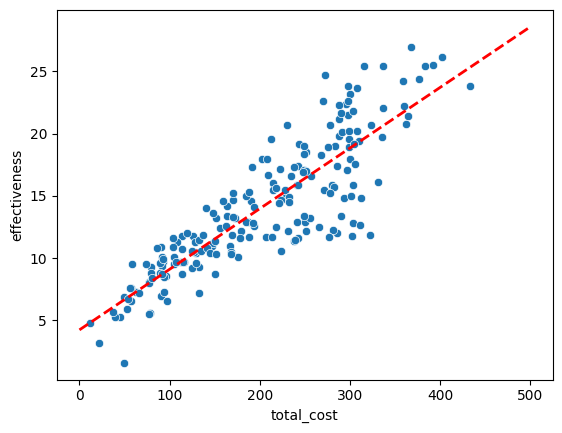

```python
ln_space = np.linspace(0, 500, 100)

line = b1*ln_space + b0
sns.scatterplot(x='total_cost', y='effectiveness', data=df)
plt.plot(ln_space, line, color='red', linestyle='--', linewidth=2, label='Regression Line 2');
```

Таким чином, отримана залежність схожа із побудованою засобами бібліотеки `seaborn`.

> **Практичне завдання 2**

> Розрахувати коефіцієнти та побудувати графік для лінійної регресії наступними даними:
> 1. Створити послідовність, використовуючи набори випадкових чисел, що дорівнюють номеру за списком.

> **Практичне завдання 3**

> **Завдання:**
> 1. Створіть власний набір даних для задачі лінійної регресії (наприклад, залежність між кількістю годин навчання та отриманою оцінкою).
> 2. Побудуйте графік розсіювання для ваших даних.
> 3. Використайте метод найменших квадратів для знаходження коефіцієнтів лінійної регресії.
> 4. Відобразіть отриману регресійну пряму на графіку.
> 5. Зробіть прогноз для нового значення ознаки (наприклад, для 10 годин навчання).